# Notes from Chapter 4 - Classificação

Henry Frederick Ridwan Surjadi

27 de maio de 2021

# Identificar problemas de classificação

O objetivo de prever se um registro é um 0 ou um 1, se for:

- 0 ou 1 (phishing/não phishing, clicar/não clicar, desistir/não desistir);
- uma entre muitas categorias (por exemplo, a filtragem do Gmail em sua caixa de entrada em “principal”, “social”, “promoções” ou “fóruns”).

A grande maioria dos problemas envolve uma resposta binária. Alguns problemas de classificação, no entanto, envolvem uma resposta com mais de dois resultados possíveis.

- Do ponto de vista de ajuste de modelo, costuma ser vantajoso converter problemas multiclasses em uma série de problemas binários.

A abordagem geral é a seguinte:

```
1. Estabelecer uma probabilidade de corte para a classe de interesse acima da qual consideramos um registro como pertencente àquela classe.

2. Estimar (com qualquer modelo) a probabilidade de um registro pertencer à classe de interesse.

3. Se tal probabilidade estiver acima da probabilidade de corte, atribuir o novo registro à classe de interesse.
```

- Quanto maior o corte, menos registro previstos como 1.
- Quanto menor o corte, mais registro previstos como 1.

# Utilizar a *Naive Bayes*

**O algoritmo Naive Bayes**

Usa a probabilidade de observação de valores preditores, dado um resultado, para estimar a probabilidade de observar o resultado Y = i, dado um conjunto de valores preditores.

## Classificação Bayesiana “não naive”

Para cada registro a ser classificado:

```
1. Encontre todos os outros registros com o mesmo perfil preditivo (ou seja, nos quais os valores preditores sejam os mesmos)

2. Determine a quais classes aqueles registros pertencem e qual classe é prevalente (ou seja, provável)

3. Atribua aquela classe ao novo registro
```

- **As variáveis preditoras devem ser variáveis categóricas(fator) no algoritmo Naive Bayes padrão**

## A Solução Naive

Na solução Naive Bayes, não restringimos mais o cálculo da probabilidade àqueles registros que se correspondem com o registro a ser classificado. Em vez disso usamos todo o conjunto de dados:

```
1.  Para uma resposta binária Y = i(i=0 ou 1), estime as probabilidades condicionais individuais para cada preditor P(Xj | Y) = i.
-   Estas são as probabilidades de o valor preditor estar no registro quando observamos Y = i;
-   Essa probabilidade é estimada pela proporção de valores Xj entre os registros Y = i no conjunto de treinamento.

2.  Multiplique essas probabilidades uma pela outra, e então pela proporção de registros pertencentes a Y = i.

3.  Repita os Passos 1 e 2 para todas as classes.

4.  Estime uma probabilidade para o resultado i assumindo o valor calculado no passo 2 para classe i e dividindo-o pela soma de tais valores para todas as classes.

5.  Atribua o registro à classe com a maior probabilidade para esse conjunto de valores preditores.
```

O Classificador Bayesiano Naive é conhecido por produzir estimativas *enviesadas*.

- Mas se o objetivo é **ordenar os registros conforme a probabilidade de Y = 1**, as estimativas de probabilidade não enviesadas não são necessárias, e o Naive Bayes produz bons resultados.

```r
loan_data <- read.csv("loan_data.csv")
library(MASS)
library(klaR)
naive_model <- NaiveBayes(as.factor(outcome) ~ purpose_ + home_ + emp_len_, data = na.omit(loan_data))
naive_model$table
```

```
## $purpose_
##           var
## grouping   credit_card debt_consolidation home_improvement major_purchase
##   default   0.15151515         0.57571347       0.05981209     0.03727229
##   paid off  0.18759649         0.55215915       0.07150104     0.05359270
##           var
## grouping      medical      other small_business
##   default  0.01433549 0.11561025     0.04574126
##   paid off 0.01424728 0.09990737     0.02099599
##
## $home_
##           var
## grouping    MORTGAGE       OWN      RENT
##   default  0.4313440 0.0832782 0.4853778
##   paid off 0.4894800 0.0808963 0.4296237
##
## $emp_len_
##           var
## grouping     < 1 Year   > 1 Year
##   default  0.04728508 0.95271492
##   paid off 0.03105289 0.96894711
```

```r
new_loan <- loan_data[147, c('purpose_', 'home_', 'emp_len_')]
row.names(new_loan) <- NULL
new_loan
```

```
##         purpose_    home_  emp_len_
## 1 small_business MORTGAGE  > 1 Year
```

```r
predict(naive_model, new_loan)
```

[output not shown]

# Utilizar a utilizar a regressão logistica

É análoga à regressão linear múltipla, exceto pelo seu resultado ser binário.

- **model** the probability of an event occurring depending on the values of the independent variables, which can be **categorical or numerical**;
- **estimate** the probability that an event occurs for a randomly selected observation versus the probability that the event does not occur;
- **predict** the effect of a series of variables on a binary response variable;
- **classify** observations by estimating the probability that an observation is in a particular category (such as approved or not approved in our problem).

A ideia conceitual principal é o entendimento da *razão de chances*:

$${odds ratio} = \frac{{Odds}(Y=1|X=1)}{{Odds}(Y=1|X=0)}$$
É interpretado como as chances de Y = 1, quando X = 1 versus as chances de Y = 1 quando X = 0.

- Se a razão de chances for 2, então as chances de Y = 1 são duas vezes maiores quando X = 1 do que quando x = 0.

Estimação de Máxima Verossimilhança(MLE) é um processo que tenta encontrar o modelo que mais provavelmente produziu os dados que observamos.

- Na equação da regressão logística, a resposta não é 0 ou 1, mas, sim, uma estimativa das chances de log de que a resposta seja 1.

```r
library(mgcv)
logistic_gam <- gam(as.factor(outcome) ~ s(payment_inc_ratio) + purpose_ +
                      home_ + emp_len_ + s(borrower_score),
                    data=loan_data, family='binomial')
```

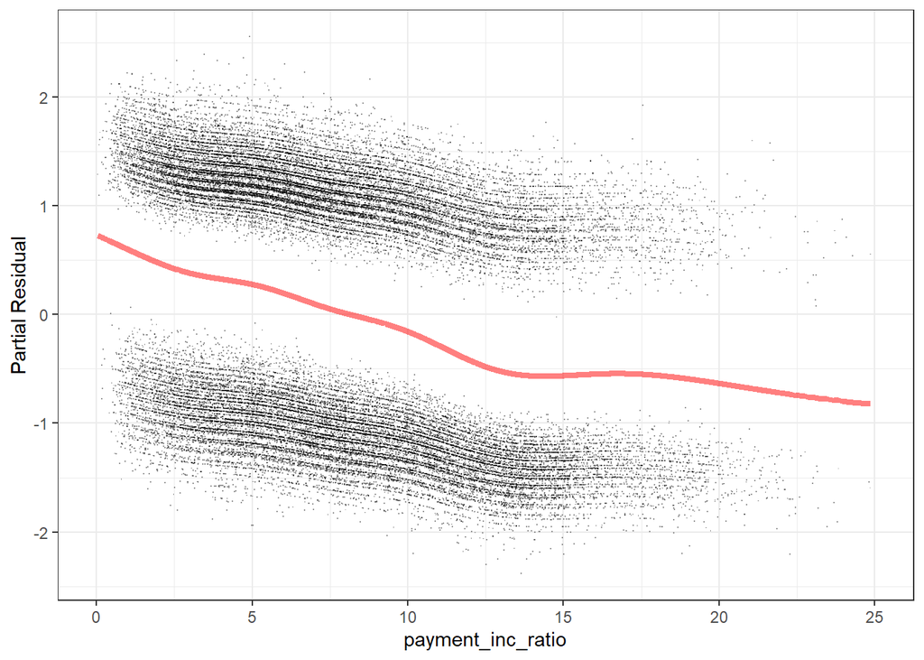

```r
library(ggplot2)
terms <- predict(logistic_gam, type='terms')
partial_resid <- resid(logistic_gam) + terms
df <- data.frame(payment_inc_ratio = loan_data[, 'payment_inc_ratio'],
                 terms = terms[, 's(payment_inc_ratio)'],
                 partial_resid = partial_resid[, 's(payment_inc_ratio)'])

ggplot(df, aes(x=payment_inc_ratio, y=partial_resid, solid = FALSE)) +
  geom_point(shape=46, alpha=.4) +
  geom_line(aes(x=payment_inc_ratio, y=terms),
            color='red', alpha=.5, size=1.5) +
  labs(y='Partial Residual') +
  xlim(0, 25) +
  theme_bw()
```

# Explicar o problema da classe rara

A classe rara geralmente é a classe de maior interesse, e costuma ser designada como 1, ao contrário dos mais prevalentes 0s. (LER A PAG. 254 novamente)

# Utilizar matriz de confusão

Matriz de confusão é uma tabela que mostra o número de previsões corretas e incorretas categorizadas por tipo de resposta.

- Os elementos diagonais da matriz mostram o número de previsões corretas
- Os elementos fora da diagonal mostram o número de previsões incorretas.

```r
#Exemplo usando a library "caret"
# https://rdrr.io/cran/caret/man/confusionMatrix.html

lvs <- c("normal", "abnormal")
truth <- factor(rep(lvs, times = c(86, 258)),
                levels = rev(lvs))
pred <- factor(
               c(
                 rep(lvs, times = c(54, 32)),
                 rep(lvs, times = c(27, 231))),
               levels = rev(lvs))

xtab <- table(pred, truth)
library(caret)
confusionMatrix(xtab)
```

```
## Confusion Matrix and Statistics
##
##           truth
## pred       abnormal normal
##   abnormal      231     32
##   normal         27     54
##
##                Accuracy : 0.8285
##                  95% CI : (0.7844, 0.8668)
##     No Information Rate : 0.75
##     P-Value [Acc > NIR] : 0.0003097
##
##                   Kappa : 0.5336
##
##  Mcnemar's Test P-Value : 0.6025370
##
##             Sensitivity : 0.8953
##             Specificity : 0.6279
##          Pos Pred Value : 0.8783
##          Neg Pred Value : 0.6667
##              Prevalence : 0.7500
##          Detection Rate : 0.6715
##    Detection Prevalence : 0.7645
##       Balanced Accuracy : 0.7616
##
##        'Positive' Class : abnormal
##
```

```r
#confusionMatrix(pred, truth)
#confusionMatrix(xtab, prevalence = 0.25)
```

OBS: TP = 231, TN = 54, FP = 32, FN = 27

# Conhecer métricas de avaliação do modelo

|  |  | Confusion | Matrix |
| --- | --- | --- | --- |
|  |  | Reference | Reference |
|  |  | Event | No Event |
| Predicted | Event | TruePositive (TP) | FalsePositive (FP) |
| Predicted | No Event | FalseNegative (FN) | TrueNegative (TN) |

### Acurácia

É simplesmente uma medida do erro total:
$$accuracy = \frac{\sum{}TruePositive+\sum{}TrueNegative}{Samplesize}$$

### Precisão

A exatidão mede a precisão de um resultado previsto como positivo:
$$precision = \frac{\sum_{}TruePositive}{\sum_{}TruePositive+\sum_{}FalsePositive}$$

### Revocação ou Recall

Recall, tambem conhecida como *sensibilidade*, mede a força do modelo em prever um resultado positivo, A proporação de 1s que identifica corretamente.
$$recall = \frac{\sum_{}TruePositive}{\sum_{}TruePositive+\sum_{}FalseNegative}$$

### Curva ROC

Característica Operatória do Receptor(ROC) plota o *recall* no eixo y contra a *specificity* no eixo x, e ela mostra a troca entre recall e specificity conforme o corte é mudado para classificar um registro. É possível encontrar duas formas:

- specificity representada no eixo x, com 1 à esquerda e 0 à direita;
- Specificity representada no eixo x, com 0 à esquerda e 1 à direita.

### Curva AUC

A AUC é simplesmente a área total sob a curva ROC. Quanto maior o valor da AUC, mais eficaz é o classificador. Uma AUC de 1 indica um classificador perfeito: * classifica todos os 1s corretamente; * e nao classifica erroneamente nenhum 0 como 1. * Um classificador completamente ineficiente terá um AUC de 0,5.

# Confusão de Taxa de Falso Positivo

O termo é usado para se referir à proporção de sinais positivos que são negativos reais.